# Graduate Admission – based on SVD analysis

Jincheng Wen

April 7, 2019

```r
Admission <- read.csv("Admission_Predict.csv", row.names = "Serial.No.")
```

The purpose of this paper is using SVD method to analyze how likely a student will be admited under his situation.This data set is from [Kaggle](https://www.kaggle.com/mohansacharya/graduate-admissionshttps://www.kaggle.com/mohansacharya/graduate-admissions), which is inspired by the UCLA Graduate Dataset.

### Data description

This data set has 8 columns

```
## [1] "GRE.Score"         "TOEFL.Score"       "University.Rating"
## [4] "SOP"               "LOR"               "CGPA"
## [7] "Research"          "Chance.of.Admit"
```

The *GRE.Score* and *TOEFL.Score* mean the standard exam grade of GRE and TOEFL. *University.Ranking* is the undergraduate school rank of all applicants. *SOP* is the statement of purpose, basically explain why you are applying to that program. *LOR* stands for Letter of Recommendation.*CGPA* is the gpa of applicants. *Research* is the research experience of students, if have, *Research* will be 1, otherwise it will be 0. *Chance.of.Admit* stands for the possibility that applicant will be admited.

And there are 400 rows, which means the number of applicants.

the data description shows as following:

```
##    GRE.Score      TOEFL.Score    University.Rating      SOP
##  Min.   :290.0   Min.   : 92.0   Min.   :1.000     Min.   :1.0
##  1st Qu.:308.0   1st Qu.:103.0   1st Qu.:2.000     1st Qu.:2.5
##  Median :317.0   Median :107.0   Median :3.000     Median :3.5
##  Mean   :316.8   Mean   :107.4   Mean   :3.087     Mean   :3.4
##  3rd Qu.:325.0   3rd Qu.:112.0   3rd Qu.:4.000     3rd Qu.:4.0
##  Max.   :340.0   Max.   :120.0   Max.   :5.000     Max.   :5.0
##       LOR             CGPA          Research      Chance.of.Admit
##  Min.   :1.000   Min.   :6.800   Min.   :0.0000   Min.   :0.3400
##  1st Qu.:3.000   1st Qu.:8.170   1st Qu.:0.0000   1st Qu.:0.6400
##  Median :3.500   Median :8.610   Median :1.0000   Median :0.7300
##  Mean   :3.453   Mean   :8.599   Mean   :0.5475   Mean   :0.7244
##  3rd Qu.:4.000   3rd Qu.:9.062   3rd Qu.:1.0000   3rd Qu.:0.8300
##  Max.   :5.000   Max.   :9.920   Max.   :1.0000   Max.   :0.9700
```

### Data wrangling

From the data set shows below, we could find that the GRE and TOEFL scores have very big adsolute value compared with other features. Therefore, this data set should be nomalized.

| GRE.Score | TOEFL.Score | University.Rating | SOP | LOR | CGPA | Research | Chance.of.Admit |
| --- | --- | --- | --- | --- | --- | --- | --- |
| 337 | 118 | 4 | 4.5 | 4.5 | 9.65 | 1 | 0.92 |
| 324 | 107 | 4 | 4.0 | 4.5 | 8.87 | 1 | 0.76 |
| 316 | 104 | 3 | 3.0 | 3.5 | 8.00 | 1 | 0.72 |
| 322 | 110 | 3 | 3.5 | 2.5 | 8.67 | 1 | 0.80 |
| 314 | 103 | 2 | 2.0 | 3.0 | 8.21 | 0 | 0.65 |

And the changes of admit column will be chosen as factor to seperate the applicants. I will cut the column to 3 part: “good”, “medium” and “bad”.

```
## [1] "good"   "medium" "bad"
```

After data clean, this data set show as following:

```
##     GRE.Score TOEFL.Score University.Rating         SOP         LOR
## 1  1.75990263  1.74478556         0.7978295  1.09249604  1.16586107
## 2  0.62687135 -0.06755072         0.7978295  0.59590693  1.16586107
## 3 -0.07037867 -0.56182425        -0.0765042 -0.39727129  0.05286721
## 4  0.45255884  0.42672281        -0.0765042  0.09931782 -1.06012666
## 5 -0.24469118 -0.72658209        -0.9508379 -1.39044950 -0.50362972
## 6  1.14980886  1.25051203         1.6721631  1.09249604 -0.50362972
##         CGPA   Research
## 1  1.7626109  0.9079746
## 2  0.4545820  0.9079746
## 3 -1.0043734  0.9079746
## 4  0.1191899  0.9079746
## 5 -0.6522117 -1.0985991
## 6  1.2427532  0.9079746
```

### Implement Singular Value Decomposition (SVD)

```r
d = AdmissionSVD$d
d
```

```
## [1] 44.094603 17.006659 14.769224 11.119885  9.891360  7.955527  7.518528
```

The singular value above represent the importance of every component acount for the whole data set. We can graph a bar chart to visualize the importance of every factor.

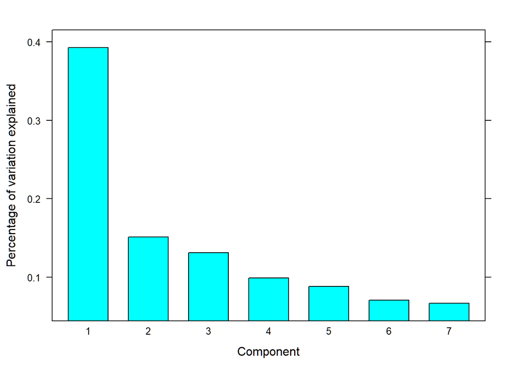

```r
u = AdmissionSVD$u
v = AdmissionSVD$v
head(u)
```

```
##              [,1]         [,2]        [,3]         [,4]        [,5]
## [1,] -0.080261280  0.019035871 -0.03591544  0.050892702  0.01529530
## [2,] -0.036948123 -0.004584072  0.06019613  0.009645927 -0.04263541
## [3,]  0.012913000  0.039996949  0.06759844 -0.008137605 -0.03498439
## [4,] -0.006707015  0.076537539 -0.01657168 -0.045817594  0.05192147
## [5,]  0.046696399 -0.002119535 -0.04487200  0.050695563 -0.04914183
## [6,] -0.059569225  0.036813684 -0.04374176 -0.116744041  0.02546160
##               [,6]         [,7]
## [1,] -0.0062452470 -0.009505469
## [2,] -0.0305458533  0.037673982
## [3,]  0.0391631520  0.074243952
## [4,] -0.0009094424  0.001115527
## [5,] -0.0198445721  0.030319486
## [6,] -0.0217358197 -0.013711175
```

```r
v
```

```
##            [,1]        [,2]         [,3]        [,4]         [,5]
## [1,] -0.3982454  0.28739503 -0.355300622  0.20387046 -0.059170869
## [2,] -0.3988544  0.12309599 -0.454531695  0.08276064  0.168684925
## [3,] -0.3877289 -0.23009197  0.006428635 -0.72848997 -0.509040696
## [4,] -0.3821831 -0.35045293  0.256850643 -0.21429656  0.767624543
## [5,] -0.3559768 -0.44949846  0.413360404  0.59221978 -0.343988700
## [6,] -0.4174264  0.02064827 -0.245186980  0.14074230 -0.035818676
## [7,] -0.2914687  0.72388997  0.608412153 -0.06658970 -0.007945579
##             [,6]        [,7]
## [1,] -0.27520046  0.71537860
## [2,]  0.72989284 -0.22608848
## [3,]  0.05132022  0.06502950
## [4,] -0.09887396  0.14212695
## [5,]  0.16813390  0.05516664
## [6,] -0.58758386 -0.63155843
## [7,]  0.07474973 -0.10382268
```

## SVD analysis

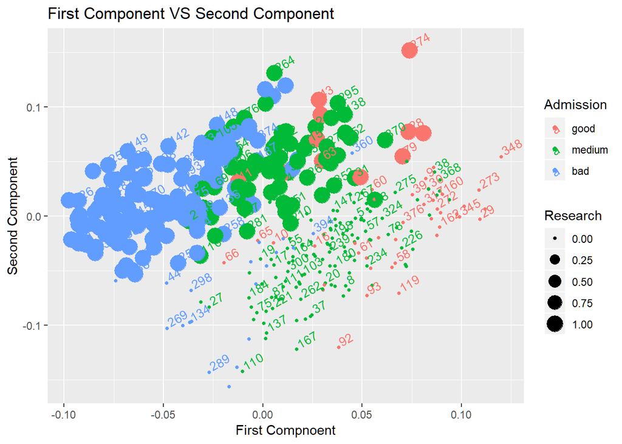

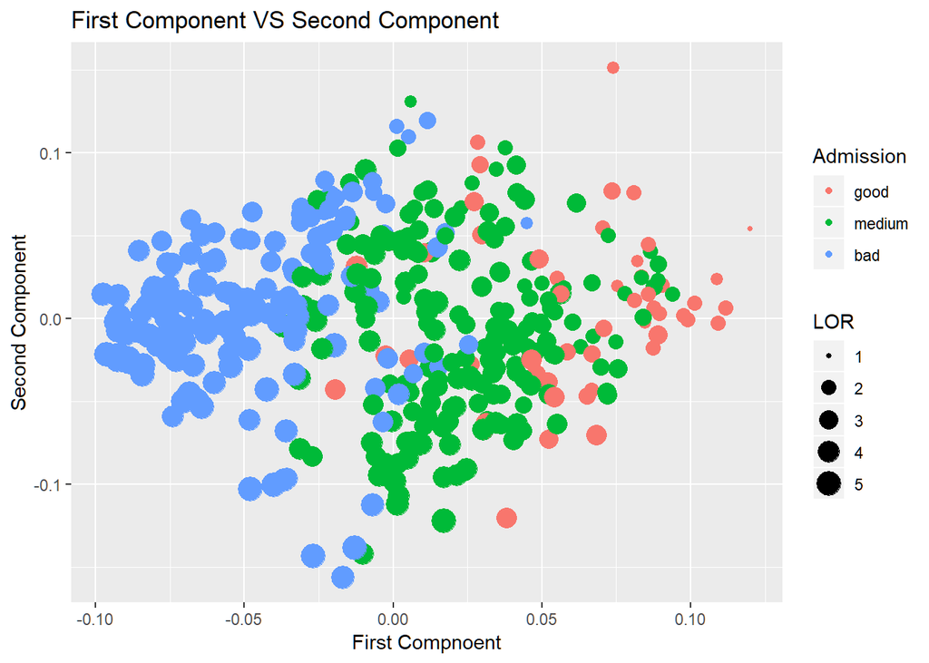

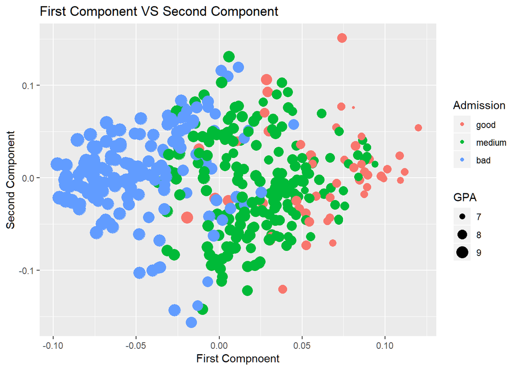

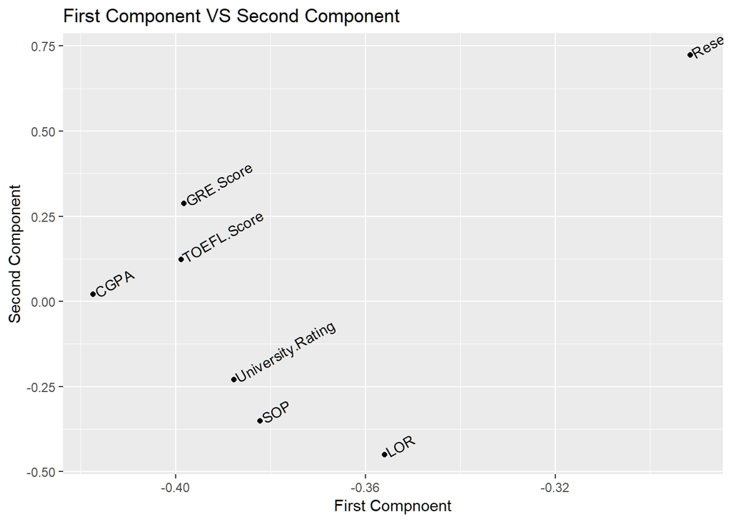